# Tugas MPDW 7

Karimatu Ain G1401211001 P2

2023-10-15

## Packages

```r
library(ggplot2)
library(tsibble)
library(tseries)
library(MASS)
library(forecast)
library(TSA)
library(TTR)
library(aTSA)
library(graphics)
library(rio)
```

## Import Data Asli

```r
data<-ts(import("https://raw.githubusercontent.com/karimatuain/mpdw/main/Data/Data%20MPDW%201.csv"))
data<-data[,-1]
View(data)
```

## Eksplorasi Data

### Plot Data Penuh

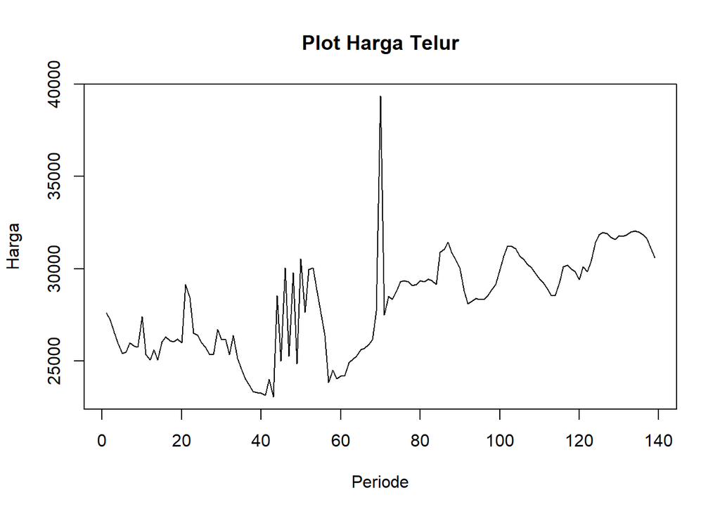

```r
plot.ts(data, xlab="Periode", ylab="Harga", main="Plot Harga Telur")
```

Berdasarkan plot data deret waktu, terlihat bahwa data cenderung memiliki trend yang naik. Berdasarkan pola data, pembagian data latih dan data uji ditetapkan dengan proporsi 80%:20%.

#### Plot Data Latih

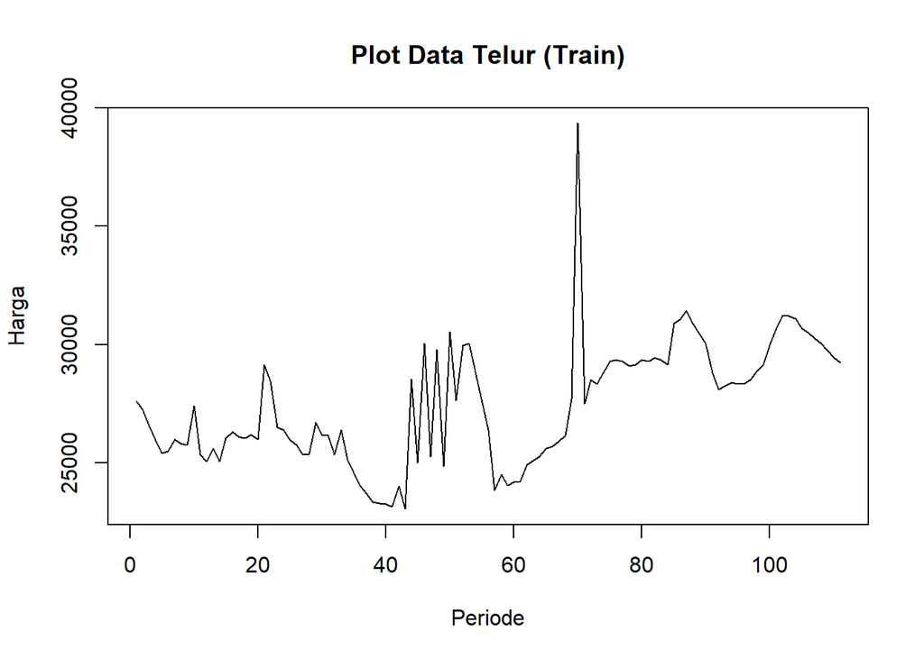

```r
data.train<-ts(data[1:111])
plot.ts(data.train, lty=1, xlab="Periode", ylab="Harga", main="Plot Data Telur (Train)")
```

Berdasarkan plot data deret waktu pada data latih, terlihat bahwa data cenderung memiliki trend yang sedikit naik dan cenderung tidak bergerak pada nilai tengah tertentu. Hal ini mengindikasikan bahwa data tidak stasioner dalam rataan.

#### Plot Data Uji

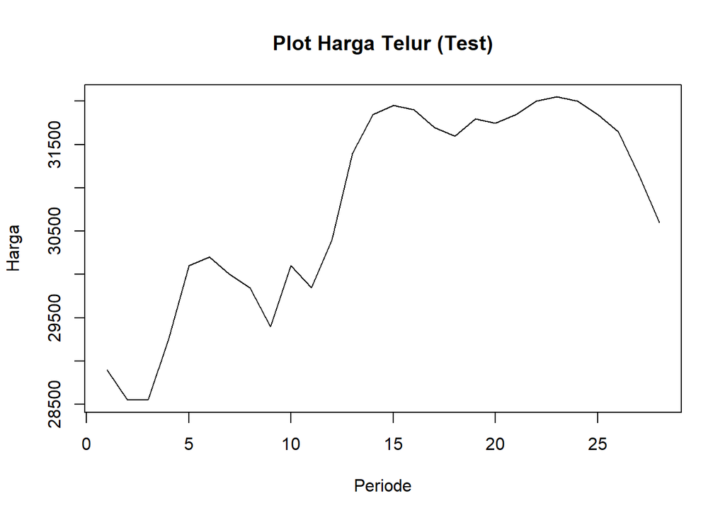

```r
data.test<-ts(data[112:139])
plot.ts(data.test, lty=1, xlab="Periode", ylab="Harga", main="Plot Harga Telur (Test)")
```

### Uji Stasioneritas Data

#### Plot ACF

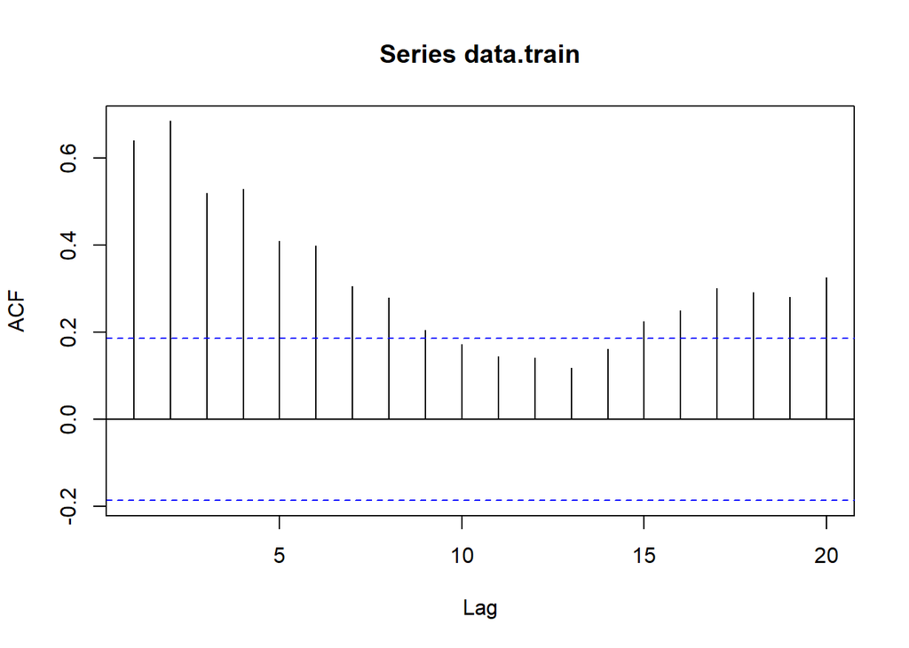

```r
acf(data.train)
```

Berdasarkan plot ACF, terlihat bahwa plot ACF data menurun secara perlahan (*tails off slowly*). Hal ini juga menjadi indikasi bahwa data tidak stasioner dalam rataan

#### Uji ADF

```r
tseries::adf.test(data.train)
```

```
##
##  Augmented Dickey-Fuller Test
##
## data:  data.train
## Dickey-Fuller = -3.3371, Lag order = 4, p-value = 0.0686
## alternative hypothesis: stationary
```

$H_0$ : Data tidak stasioner dalam rataan

$H_1$ : Data stasioner dalam rataan

Berdasarkan uji ADF tersebut, didapat *p-value* sebesar 0.0686 yang lebih besar dari taraf nyata 5% sehingga tak tolak $H_0$ dan menandakan bahwa data tidak stasioner dalam rataan. Hal ini sesuai dengan hasil eksplorasi menggunakan plot time series dan plot ACF, sehingga ketidakstasioneran model kedepannya harus ditangani

#### Plot Box-Cox

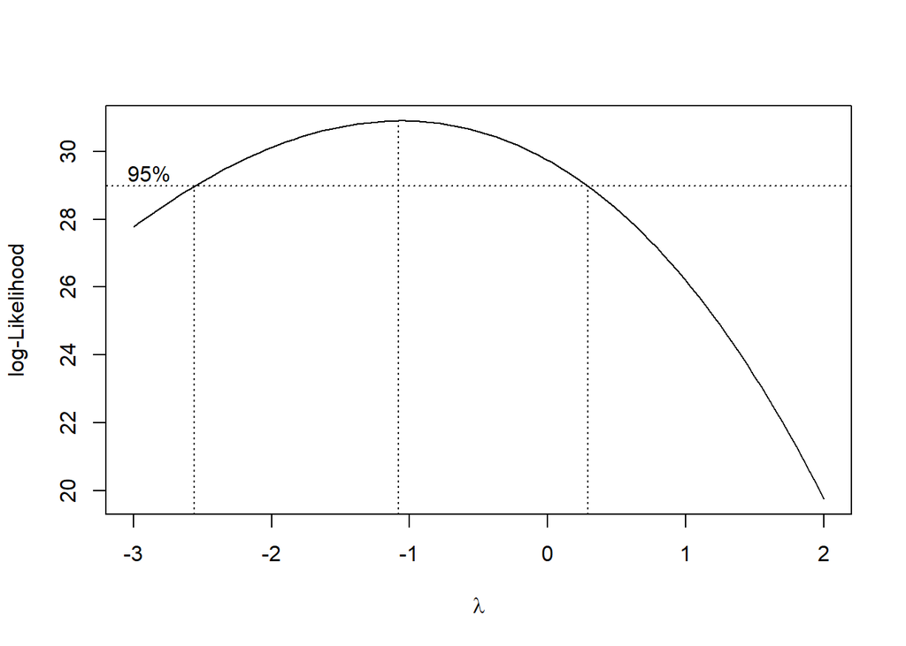

```r
index <- seq(1:111)
bc1 = boxcox(data.train~index, lambda = seq(-3,2,by=1))
```

```r
#Nilai Rounded Lambda
lambda <- bc1$x[which.max(bc1$y)]
lambda
```

```
## [1] -1.080808
```

```r
#SK
bc1$x[bc1$y > max(bc1$y) - 1/2 * qchisq(.95,1)]
```

```
##  [1] -2.54545455 -2.49494949 -2.44444444 -2.39393939 -2.34343434 -2.29292929
##  [7] -2.24242424 -2.19191919 -2.14141414 -2.09090909 -2.04040404 -1.98989899
## [13] -1.93939394 -1.88888889 -1.83838384 -1.78787879 -1.73737374 -1.68686869
## [19] -1.63636364 -1.58585859 -1.53535354 -1.48484848 -1.43434343 -1.38383838
## [25] -1.33333333 -1.28282828 -1.23232323 -1.18181818 -1.13131313 -1.08080808
## [31] -1.03030303 -0.97979798 -0.92929293 -0.87878788 -0.82828283 -0.77777778
## [37] -0.72727273 -0.67676768 -0.62626263 -0.57575758 -0.52525253 -0.47474747
## [43] -0.42424242 -0.37373737 -0.32323232 -0.27272727 -0.22222222 -0.17171717
## [49] -0.12121212 -0.07070707 -0.02020202  0.03030303  0.08080808  0.13131313
## [55]  0.18181818  0.23232323  0.28282828
```

Plot Boxcox menunjukkan nilai *rounded value* ($\lambda$) optimum sebesar **-1.0808** dan pada selang kepercayaan 95% nilai memiliki batas bawah **-2.5454** dan batas atas **0.2828**. Selang tersebut tidak memuat nilai satu sehingga dapat dikatakan bahwa data tidak stasioner dalam ragam.

### Penanganan Ketidakstasioneran Data

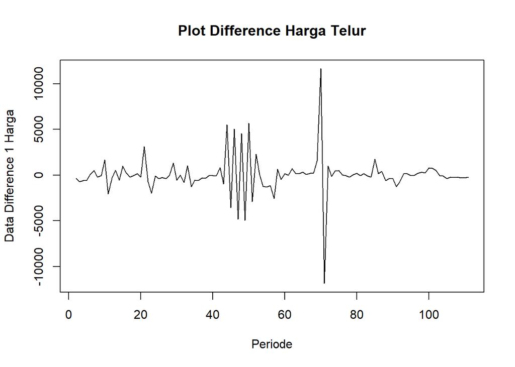

```r
train.diff<-diff(data.train,differences = 1)
plot.ts(train.diff, lty=1, xlab="Periode", ylab="Data Difference 1 Harga", main="Plot Difference Harga Telur")
```

Berdasarkan plot data deret waktu, terlihat bahwa data sudah stasioner dalam rataan ditandai dengan data bergerak pada nilai tengah tertentu (tidak terdapat trend ataupun musiman pada data)

#### Plot ACF

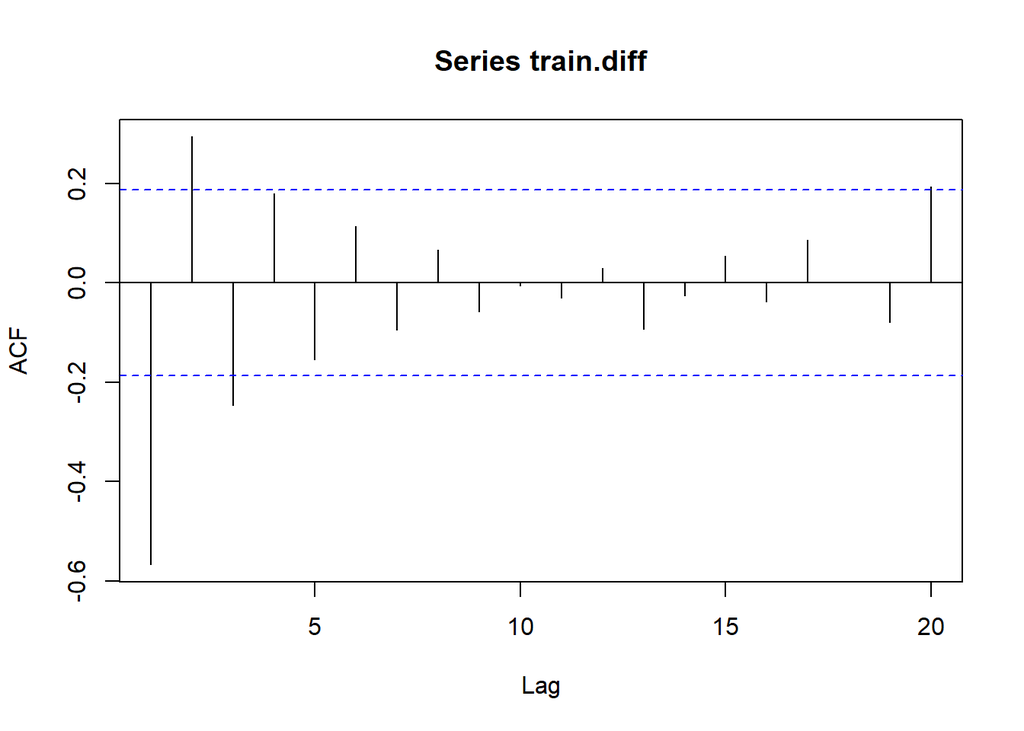

```r
acf(train.diff)
```

#### Uji ADF

```r
tseries::adf.test(train.diff)
```

```
##
##  Augmented Dickey-Fuller Test
##
## data:  train.diff
## Dickey-Fuller = -5.6665, Lag order = 4, p-value = 0.01
## alternative hypothesis: stationary
```

$H_0$ : Data tidak stasioner dalam rataan

$H_1$ : Data stasioner dalam rataan

Berdasarkan uji ADF tersebut, didapat *p-value* sebesar 0.01 yang lebih kecil dari taraf nyata 5% sehingga tolak $H_0$ atau data stasioner dalam rataan. Hal ini sesuai dengan hasil eksplorasi menggunakan plot time series dan plot ACF, sehingga dalam hal ini ketidakstasioneran data sudah berhasil ditangani dan dapat dilanjutkan ke pemodelan

### Identifikasi Model

#### Plot ACF

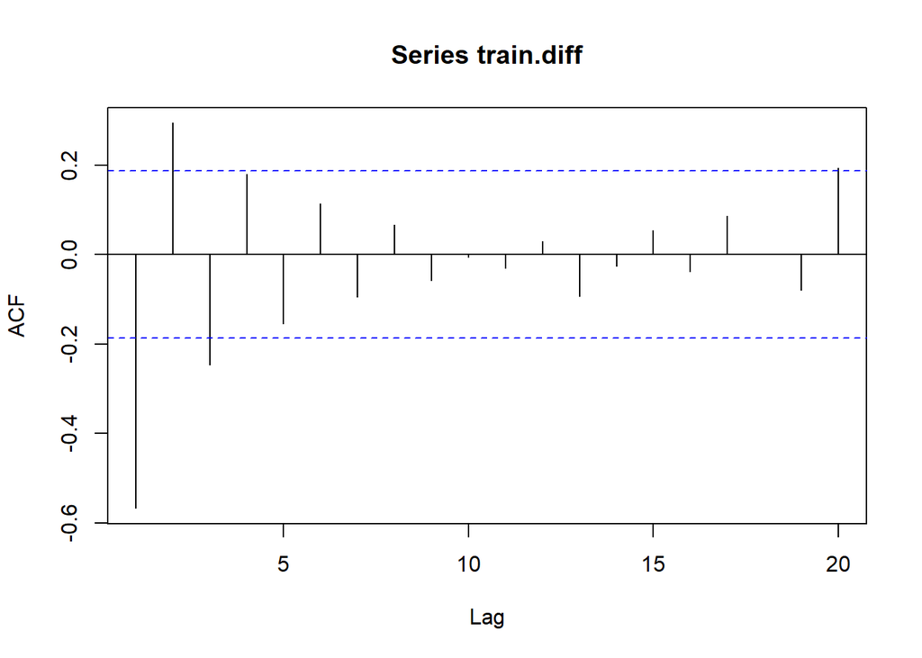

```r
acf(train.diff)
```

Berdasarkan plot tersebut, terlihat bahwa plot ACF cenderung *cuts off* pada lag ke 1, sehingga jika plot PACF dianggap *tails of*, maka model tentatifnya adalah ARIMA(0,1,1).

#### Plot PACF

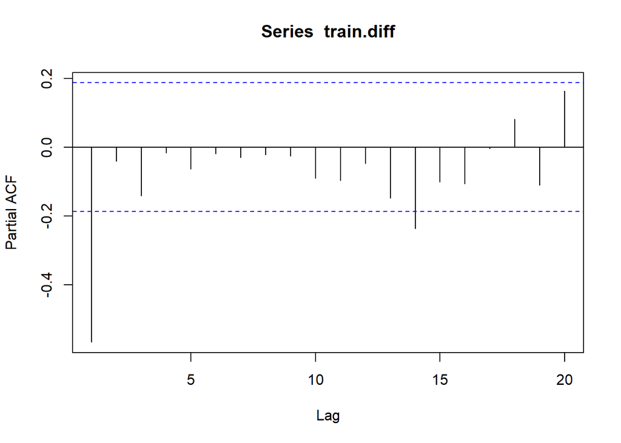

```r
pacf(train.diff)
```

Berdasarkan plot tersebut, terlihat bahwa plot PACF cenderung *cuts off* pada lag ke 1, sehingga jika plot ACF dianggap *tails of*, maka model tentatifnya adalah ARIMA(1,1,0).

Jika baik plot ACF maupun plot PACF keduanya dianggap tails of, maka model yang terbentuk adalah ARIMA(1,1,1)

#### Plot EACF

```r
eacf(train.diff)
```

```
## AR/MA
##   0 1 2 3 4 5 6 7 8 9 10 11 12 13
## 0 x x x o o o o o o o o  o  o  o
## 1 o x o o o o o o o o o  o  o  o
## 2 x x o o o o o o o o o  o  o  o
## 3 o x o o o o o o o o o  o  o  o
## 4 x x o o o o o o o o o  o  o  o
## 5 x x o o o o o o o o o  o  o  o
## 6 x x o o o o o o o o o  o  o  o
## 7 x x o o o o o o o o o  o  o  o
```

Identifikasi model menggunakan plot EACF dilakukan dengan melihat ujung segitiga pada pola segitiga nol. Dalam hal ini model tentatif yang terbentuk adalah ARIMA(1,1,2) dan ARIMA(2,1,2)

### Pendugaan Parameter Model Tentatif

#### ARIMA(0,1,1)

```r
model1.da=Arima(train.diff, order=c(0,1,1),method="ML")
summary(model1.da) #AIC=1993.51
```

```
## Series: train.diff
## ARIMA(0,1,1)
##
## Coefficients:
##           ma1
##       -1.0000
## s.e.   0.0231
##
## sigma^2 = 4782943:  log likelihood = -994.75
## AIC=1993.51   AICc=1993.62   BIC=1998.89
##
## Training set error measures:
##                   ME     RMSE      MAE MPE MAPE      MASE       ACF1
## Training set 66.3026 2167.021 1022.232 NaN  Inf 0.5859755 -0.5680563
```

```r
lmtest::coeftest(model1.da) #seluruh parameter signifikan
```

```
##
## z test of coefficients:
##
##      Estimate Std. Error z value  Pr(>|z|)
## ma1 -1.000000   0.023145 -43.206 < 2.2e-16 ***
## ---
## Signif. codes:  0 '***' 0.001 '**' 0.01 '*' 0.05 '.' 0.1 ' ' 1
```

#### ARIMA(1,1,0)

```r
model2.da=Arima(train.diff, order=c(1,1,0),method="ML")
summary(model2.da) #AIC=2014.18
```

```
## Series: train.diff
## ARIMA(1,1,0)
##
## Coefficients:
##           ar1
##       -0.7681
## s.e.   0.0596
##
## sigma^2 = 5987404:  log likelihood = -1005.09
## AIC=2014.18   AICc=2014.29   BIC=2019.56
##
## Training set error measures:
##                    ME    RMSE     MAE MPE MAPE     MASE       ACF1
## Training set 2.854058 2424.57 1159.61 NaN  Inf 0.664725 -0.3013667
```

```r
lmtest::coeftest(model2.da) #seluruh parameter signifikan
```

```
##
## z test of coefficients:
##
##      Estimate Std. Error z value  Pr(>|z|)
## ar1 -0.768116   0.059572 -12.894 < 2.2e-16 ***
## ---
## Signif. codes:  0 '***' 0.001 '**' 0.01 '*' 0.05 '.' 0.1 ' ' 1
```

#### ARIMA(1,1,1)

```r
model3.da=Arima(train.diff, order=c(1,1,1),method="ML")
summary(model3.da) #AIC=1954.49
```

```
## Series: train.diff
## ARIMA(1,1,1)
##
## Coefficients:
##           ar1      ma1
##       -0.5581  -1.0000
## s.e.   0.0784   0.0253
##
## sigma^2 = 3275904:  log likelihood = -974.25
## AIC=1954.49   AICc=1954.72   BIC=1962.57
##
## Training set error measures:
##                    ME     RMSE      MAE MPE MAPE      MASE       ACF1
## Training set 102.1352 1785.094 938.9065 NaN  Inf 0.5382109 -0.0339936
```

```r
lmtest::coeftest(model3.da) #seluruh parameter signifikan
```

```
##
## z test of coefficients:
##
##      Estimate Std. Error  z value  Pr(>|z|)
## ar1 -0.558103   0.078395  -7.1191 1.086e-12 ***
## ma1 -1.000000   0.025256 -39.5942 < 2.2e-16 ***
## ---
## Signif. codes:  0 '***' 0.001 '**' 0.01 '*' 0.05 '.' 0.1 ' ' 1
```

#### ARIMA(1,1,2)

```r
model4.da=Arima(train.diff, order=c(1,1,2),method="ML")
summary(model4.da) #AIC=1956.29
```

```
## Series: train.diff
## ARIMA(1,1,2)
##
## Coefficients:
##           ar1      ma1     ma2
##       -0.4849  -1.1069  0.1069
## s.e.   0.1854   0.2330  0.2316
##
## sigma^2 = 3296440:  log likelihood = -974.14
## AIC=1956.29   AICc=1956.67   BIC=1967.05
##
## Training set error measures:
##                    ME     RMSE      MAE MPE MAPE      MASE         ACF1
## Training set 107.4834 1782.293 951.3636 NaN  Inf 0.5453517 -0.009807154
```

```r
lmtest::coeftest(model4.da) #Terdapat parameter yang tidak signifikan
```

```
##
## z test of coefficients:
##
##     Estimate Std. Error z value  Pr(>|z|)
## ar1 -0.48486    0.18540 -2.6152  0.008918 **
## ma1 -1.10688    0.23302 -4.7501 2.033e-06 ***
## ma2  0.10689    0.23161  0.4615  0.644442
## ---
## Signif. codes:  0 '***' 0.001 '**' 0.01 '*' 0.05 '.' 0.1 ' ' 1
```

#### ARIMA(2,1,2)

```r
model5.da=Arima(train.diff, order=c(2,1,2),method="ML")
summary(model5.da) #AIC=1953.54
```

```
## Series: train.diff
## ARIMA(2,1,2)
##
## Coefficients:
##          ar1     ar2      ma1     ma2
##       0.3053  0.4259  -1.9651  0.9667
## s.e.  0.1041  0.0987   0.0703  0.0692
##
## sigma^2 = 3141530:  log likelihood = -971.77
## AIC=1953.54   AICc=1954.13   BIC=1967
##
## Training set error measures:
##                   ME     RMSE      MAE  MPE MAPE      MASE        ACF1
## Training set 206.313 1731.685 950.1623 -Inf  Inf 0.5446631 -0.00552943
```

```r
lmtest::coeftest(model5.da) #Seluruh parameter signifikan
```

```
##
## z test of coefficients:
##
##      Estimate Std. Error  z value  Pr(>|z|)
## ar1  0.305324   0.104062   2.9341  0.003346 **
## ar2  0.425875   0.098650   4.3170 1.582e-05 ***
## ma1 -1.965102   0.070323 -27.9438 < 2.2e-16 ***
## ma2  0.966722   0.069186  13.9727 < 2.2e-16 ***
## ---
## Signif. codes:  0 '***' 0.001 '**' 0.01 '*' 0.05 '.' 0.1 ' ' 1
```

Berdasarkan pendugaan parameter di atas, nilai AIC terkecil dimiliki oleh model ARIMA(2,1,2) dan parameter model ARIMA(2,1,2) juga seluruhnya signifikan sehingga model yang dipilih adalah model ARIMA(2,1,2).

### Analisis Sisaan

Model terbaik hasil identifikasi kemudian dicek asumsi sisaannya. Sisaan model ARIMA harus memenuhi asumsi normalitas, kebebasan sisaan, dan kehomogenan ragam. Diagnostik model dilakukan secara eksplorasi dan uji formal.

#### Eksplorasi Sisaan

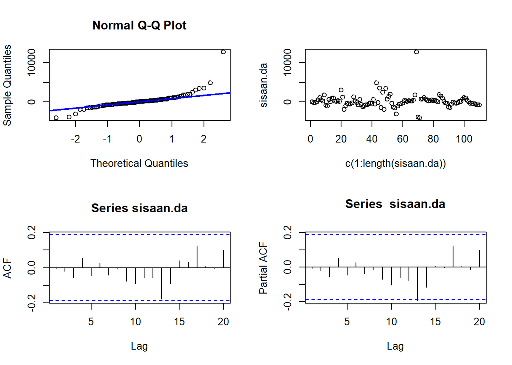

```r
#Eksplorasi
sisaan.da <- model5.da$residuals
par(mfrow=c(2,2))
qqnorm(sisaan.da)
qqline(sisaan.da, col = "blue", lwd = 2)
plot(c(1:length(sisaan.da)),sisaan.da)
acf(sisaan.da)
pacf(sisaan.da)
```

```r
par(mfrow = c(1,1))
```

Berdasarkan plot kuantil-kuantil normal, secara eksplorasi ditunjukkan sisaan tidak menyebar normal ditandai dengan titik titik yang cenderung tidak mengikuti garis $45^{\circ}$. Kemudian dapat dilihat juga lebar pita sisaan yang cenderung tidak sama menandakan bahwa sisaan memiliki ragam yang heterogen. Plot ACF dan PACF sisaan ARIMA(2,1,2) juga tidak signifikan pada 20 lag awal yang menandakan saling bebas. Kondisi ini akan diuji lebih lanjut dengan uji formal.

#### Uji Formal

```r
#1) Sisaan Menyebar Normal
ks.test(sisaan.da,"pnorm")  #tak tolak H0 > sisaan menyebar normal
```

```
##
##  Asymptotic one-sample Kolmogorov-Smirnov test
##
## data:  sisaan.da
## D = 0.53636, p-value < 2.2e-16
## alternative hypothesis: two-sided
```

Selain dengan eksplorasi, asumsi tersebut dapat diuji menggunakan uji formal. Pada tahapan ini uji formal yang digunakan untuk normalitas adalah uji Kolmogorov-Smirnov (KS). Hipotesis pada uji KS adalah sebagai berikut.

$H_0$ : Sisaan menyebar normal

$H_1$ : Sisaan tidak menyebar normal

Berdasarkan uji KS tersebut, didapat *p-value* sebesar 0.00 yang kurang dari taraf nyata 5% sehingga tolak $H_0$ dan menandakan bahwa sisaan tidak menyebar normal. Hal ini sesuai dengan hasil eksplorasi menggunakan plot kuantil-kuantil normal.

```r
#2) Sisaan saling bebas/tidak ada autokorelasi
Box.test(sisaan.da, type = "Ljung")  #tak tolak H0 > sisaan saling bebas
```

```
##
##  Box-Ljung test
##
## data:  sisaan.da
## X-squared = 0.0034558, df = 1, p-value = 0.9531
```

Selanjutnya akan dilakukan uji formal untuk kebebasan sisaan menggunakan uji Ljung-Box. Hipotesis yang digunakan adalah sebagai berikut.

$H_0$ : Sisaan saling bebas

$H_1$ : Sisaan tidak tidak saling bebas

```r
#3) Sisaan homogen
Box.test((sisaan.da)^2, type = "Ljung")  #tak tolak H0 > sisaan homogen
```

```
##
##  Box-Ljung test
##
## data:  (sisaan.da)^2
## X-squared = 0.84128, df = 1, p-value = 0.359
```

Hipotesis yang digunakan untuk uji kehomogenan ragam adalah sebagai berikut.

$H_0$ : Ragam sisaan homogen

$H_1$ : Ragam sisaan tidak homogen

```r
#4) Nilai tengah sisaan sama dengan nol
t.test(sisaan.da, mu = 0, conf.level = 0.95)  #tak tolak h0 > nilai tengah sisaan sama dengan 0
```

```
##
##  One Sample t-test
##
## data:  sisaan.da
## t = 1.2528, df = 109, p-value = 0.213
## alternative hypothesis: true mean is not equal to 0
## 95 percent confidence interval:
##  -120.0852  532.7113
## sample estimates:
## mean of x
##   206.313
```

Terakhir, dengan uji-t, akan dicek apakah nilai tengah sisaan sama dengan nol. Hipotesis yang diujikan sebagai berikut.

$H_0$ : nilai tengah sisaan sama dengan 0

$H_1$ : nilai tengah sisaan tidak sama dengan 0

Berdasarkan uji-ttersebut, didapat *p-value* sebesar 0.213 yang lebih besar dari taraf nyata 5% sehingga tak tolak $H_0$ dan menandakan bahwa nilai tengah sisaan sama dengan nol. Hal ini berbeda dengan eksplorasi.

### Peramalan

```r
#---FORECAST---#
ramalan.da <- forecast::forecast(model5.da, h = 27)
ramalan.da
```

```
##     Point Forecast     Lo 80    Hi 80     Lo 95    Hi 95
## 112      497.69490 -1775.352 2770.742 -2978.630 3974.020
## 113       86.32971 -2635.140 2807.800 -4075.800 4248.459
## 114      257.86071 -2511.887 3027.608 -3978.103 4493.824
## 115      135.04321 -2675.367 2945.453 -4163.108 4433.194
## 116      170.59480 -2640.885 2982.075 -4129.193 4470.382
## 117      129.14470 -2687.799 2946.088 -4178.998 4437.288
## 118      131.62952 -2685.362 2948.621 -4176.587 4439.846
## 119      114.73565 -2703.279 2932.750 -4195.046 4424.517
## 120      110.63577 -2707.502 2928.774 -4199.334 4420.606
## 121      102.18931 -2716.185 2920.564 -4208.143 4412.522
## 122       97.86437 -2720.571 2916.300 -4212.560 4408.289
## 123       92.94674 -2725.541 2911.435 -4217.559 4403.452
## 124       89.60338 -2728.899 2908.106 -4220.924 4400.131
## 125       86.48828 -2732.020 2904.997 -4224.048 4397.025
## 126       84.11332 -2734.394 2902.621 -4226.422 4394.648
## 127       82.06154 -2736.444 2900.567 -4228.471 4392.594
## 128       80.42365 -2738.081 2898.929 -4230.108 4390.955
## 129       79.04976 -2739.457 2897.557 -4231.485 4389.585
## 130       77.93275 -2740.580 2896.446 -4232.611 4388.476
## 131       77.00659 -2741.515 2895.528 -4233.550 4387.564
## 132       76.24811 -2742.286 2894.782 -4234.328 4386.824
## 133       75.62210 -2742.927 2894.171 -4234.977 4386.221
## 134       75.10794 -2743.459 2893.675 -4235.519 4385.734
## 135       74.68436 -2743.903 2893.272 -4235.973 4385.342
## 136       74.33606 -2744.274 2892.946 -4236.356 4385.028
## 137       74.04932 -2744.585 2892.683 -4236.680 4384.778
## 138       73.81345 -2744.846 2892.473 -4236.955 4384.582
```

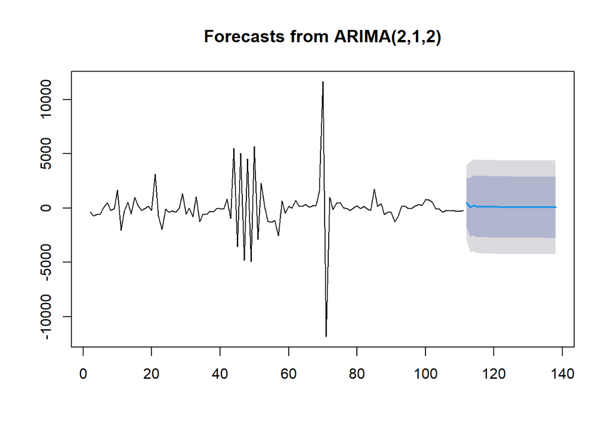

```r
data.ramalan.da <- ramalan.da$mean
plot(ramalan.da)
```

Berdasarkan hasil plot ramalan di atas, dapat dilihat bahwa ramalan ARIMA(2,1,2) cenderung stabil hingga akhir periode. Selanjutnya, dapat dicari nilai akurasi antara hasil ramalan dengan data uji sebagai berikut.

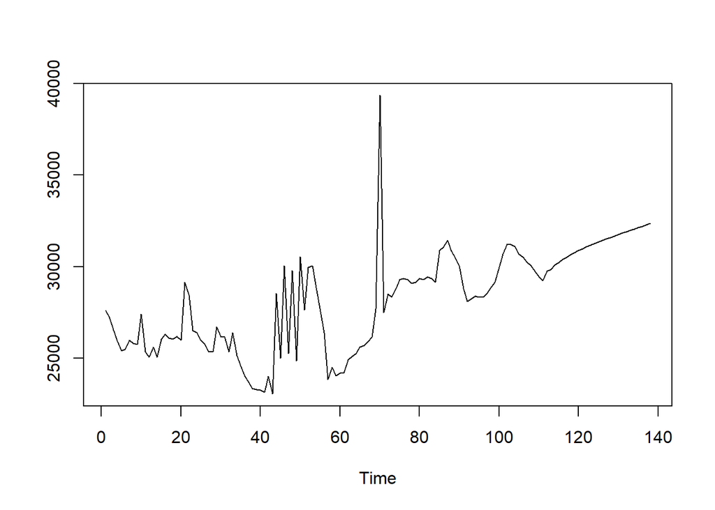

```r
pt_1 <- data.train[111] #nilai akhir data latih
hasil.forc.Diff <- data.ramalan.da
hasil <- diffinv(hasil.forc.Diff, differences = 1) + pt_1
#has.1 sama hasilnta dengan: cumsum(c(pt_1,hasil.forc.Diff))
ts.plot(data.train,hasil)
```

```r
perbandingan.da<-matrix(data=c(head(data.test, n=27), hasil[-1]),
                     nrow = 27, ncol = 2)
colnames(perbandingan.da)<-c("Aktual","Hasil Forecast")
perbandingan.da
```

```
##       Aktual Hasil Forecast
##  [1,]  28900       29747.69
##  [2,]  28550       29834.02
##  [3,]  28550       30091.89
##  [4,]  29250       30226.93
##  [5,]  30100       30397.52
##  [6,]  30200       30526.67
##  [7,]  30000       30658.30
##  [8,]  29850       30773.03
##  [9,]  29400       30883.67
## [10,]  30100       30985.86
## [11,]  29850       31083.72
## [12,]  30400       31176.67
## [13,]  31400       31266.27
## [14,]  31850       31352.76
## [15,]  31950       31436.87
## [16,]  31900       31518.94
## [17,]  31700       31599.36
## [18,]  31600       31678.41
## [19,]  31800       31756.34
## [20,]  31750       31833.35
## [21,]  31850       31909.60
## [22,]  32000       31985.22
## [23,]  32050       32060.33
## [24,]  32000       32135.01
## [25,]  31850       32209.35
## [26,]  31650       32283.40
## [27,]  31150       32357.21
```

```r
accuracy(ts(hasil[-1]), head(data.test, n=27))
```

```
##                 ME     RMSE      MAE       MPE     MAPE      ACF1 Theil's U
## Test set -448.8291 745.3445 573.5873 -1.521246 1.912995 0.7619498  1.869941
```

MAPE yang dihasilkan dari pemodelan ini <10% sehingga dapat disimpulkan bahwa hasil ramalan sudah dinilai baik.